# PeerAssigmtMo08We04

Henri

6/10/2020

## Peer-graded Assignment: Prediction Assignment Writeup

## Background

Using devices such as Jawbone Up, Nike FuelBand, and Fitbit it is now possible to collect a large amount of data about personal activity relatively inexpensively. These type of devices are part of the quantified self movement – a group of enthusiasts who take measurements about themselves regularly to improve their health, to find patterns in their behavior, or because they are tech geeks. One thing that people regularly do is quantify how much of a particular activity they do, but they rarely quantify how well they do it. In this project, your goal will be to use data from accelerometers on the belt, forearm, arm, and dumbell of 6 participants. They were asked to perform barbell lifts correctly and incorrectly in 5 different ways. More information is available from the website here: http://web.archive.org/web/20161224072740/http:/groupware.les.inf.puc-rio.br/har (see the section on the Weight Lifting Exercise Dataset).

## Load Data and Initial Setup

## Clean Data

Examined the data with the View() command and it has 160 columns/var´s and most of them have N/A in it. The strategy for cleaning the data is commence from the Test (NikTest) file making it smaller(NTestSm)by excluding all N/A content columns. Then take the name of the remaining columns and with these create a smaller Train (NTrainSm) file without excluding the “classe” column which is key for the prediction.

```r
NTestSm <- NikTest[colSums(!is.na(NikTest)) > 0] ## Clear all N/A content columns
validColn <- c(names(NTestSm[-60]),"classe") ## get valid column names - "problem_id" + "classe"
NTrainSm <- NikTrain[,validColn] ## extract the valid column names from Original Train file
## Extract the near zero values with function(nearZeroValue)
nzval <- nearZeroVar(NTrainSm); NTrainSm <- NTrainSm[, -nzval] ; NTestSm <- NTestSm[, -nzval]
## Get rid of the first five columns because the content is non numbers
NTrainSm <- NTrainSm[, -(1:5)]
NTestSm <- NTestSm[, -(1:5)]
dim(NTestSm); dim(NTrainSm) ## look at the dimension of the files
```

```
## [1] 20 54
```

```
## [1] 19622    54
```

```r
## make variable "classe" in NTrainSm a factor variable
NTrainSm$classe <- factor(NTrainSm$classe)

##Devide the Train data set into Train and Validation sets
set.seed(8128)
inTrain = createDataPartition(NTrainSm$classe, p = 1/2)[[1]]
  trainit = NTrainSm[ inTrain,]
  validatit = NTrainSm[-inTrain,]
```

## Use three differnt Modeling techniques

## First Model Rpart

```r
## FIT A RPART MODEL

library(rattle)
limRpart <- trainControl(method = "cv", number = 5, verboseIter = FALSE)
NikModRpart <- train(classe ~ .,method="rpart",data=trainit,trControl = limRpart)

Pred_RpartTestSm <- predict(NikModRpart, validatit)
confusionMatrix(validatit$classe, Pred_RpartTestSm)$overall['Accuracy']
```

```
##  Accuracy
## 0.4945973
```

```r
table(real=validatit$classe, Pred_RpartTestSm)
```

```
##     Pred_RpartTestSm
## real    A    B    C    D    E
##    A 2513   40  199    0   38
##    B  805  645  448    0    0
##    C  793   50  868    0    0
##    D  727  266  615    0    0
##    E  245  224  508    0  826
```

```r
## See appendix II for graph of tree
```

## Second Model GBM

```r
## Fit a GBM model on the "trainit" data
limGBM <- trainControl(method = "cv", number = 3)
NikModGBM <- train(classe ~ ., method = "gbm", data = trainit, trControl = limGBM, verbose=FALSE)

## predict on the validation "validatit" data and see the accuracy

Pred_validatGBM <- predict(NikModGBM, validatit)
confusionMatrix(validatit$classe, Pred_validatGBM)$overall['Accuracy']
```

```
##  Accuracy
## 0.9867482
```

```r
table(real=validatit$classe,Pred_validatGBM)
```

```
##     Pred_validatGBM
## real    A    B    C    D    E
##    A 2781    7    0    0    2
##    B   14 1867   17    0    0
##    C    0   17 1685    8    1
##    D    1    9   14 1578    6
##    E    3   20    2    9 1769
```

## Third Model RF

```r
## FIT an RF model on "trainit" data

limRF <- trainControl(method = "cv", number = 3, verboseIter = FALSE)
NikModRF <- train(classe ~ ., method = "rf", data = trainit, trControl = limRF)

## predict on the validation data and see the accuracy
Pred_val_RF <- predict(NikModRF, validatit)
confusionMatrix(validatit$classe, Pred_val_RF)$overall['Accuracy']
```

```
##  Accuracy
## 0.9959225
```

```r
table(real=validatit$classe,Pred_val_RF)
```

```
##     Pred_val_RF
## real    A    B    C    D    E
##    A 2789    0    0    0    1
##    B    8 1887    1    2    0
##    C    0    5 1696   10    0
##    D    0    0    8 1599    1
##    E    0    1    1    2 1799
```

It looks like the best model is RF, thus will now predict on the Test file and get the results for the Quiz.

```r
## predict on the test file

Pred_NTestSm <- predict(NikModRF, NTestSm)
table(NTestSm$problem_id, Pred_NTestSm)
```

```
##     Pred_NTestSm
##      A B C D E
##   1  0 1 0 0 0
##   2  1 0 0 0 0
##   3  0 1 0 0 0
##   4  1 0 0 0 0
##   5  1 0 0 0 0
##   6  0 0 0 0 1
##   7  0 0 0 1 0
##   8  0 1 0 0 0
##   9  1 0 0 0 0
##   10 1 0 0 0 0
##   11 0 1 0 0 0
##   12 0 0 1 0 0
##   13 0 1 0 0 0
##   14 1 0 0 0 0
##   15 0 0 0 0 1
##   16 0 0 0 0 1
##   17 1 0 0 0 0
##   18 0 1 0 0 0
##   19 0 1 0 0 0
##   20 0 1 0 0 0
```

## APPENDIX I., II.

APPENDIX I. File details

```r
## These are the valid column names - non N/A in the test file
validColn
```

```
##  [1] "X"                    "user_name"            "raw_timestamp_part_1"
##  [4] "raw_timestamp_part_2" "cvtd_timestamp"       "new_window"
##  [7] "num_window"           "roll_belt"            "pitch_belt"
## [10] "yaw_belt"             "total_accel_belt"     "gyros_belt_x"
## [13] "gyros_belt_y"         "gyros_belt_z"         "accel_belt_x"
## [16] "accel_belt_y"         "accel_belt_z"         "magnet_belt_x"
## [19] "magnet_belt_y"        "magnet_belt_z"        "roll_arm"
## [22] "pitch_arm"            "yaw_arm"              "total_accel_arm"
## [25] "gyros_arm_x"          "gyros_arm_y"          "gyros_arm_z"
## [28] "accel_arm_x"          "accel_arm_y"          "accel_arm_z"
## [31] "magnet_arm_x"         "magnet_arm_y"         "magnet_arm_z"
## [34] "roll_dumbbell"        "pitch_dumbbell"       "yaw_dumbbell"
## [37] "total_accel_dumbbell" "gyros_dumbbell_x"     "gyros_dumbbell_y"
## [40] "gyros_dumbbell_z"     "accel_dumbbell_x"     "accel_dumbbell_y"
## [43] "accel_dumbbell_z"     "magnet_dumbbell_x"    "magnet_dumbbell_y"
## [46] "magnet_dumbbell_z"    "roll_forearm"         "pitch_forearm"
## [49] "yaw_forearm"          "total_accel_forearm"  "gyros_forearm_x"
## [52] "gyros_forearm_y"      "gyros_forearm_z"      "accel_forearm_x"
## [55] "accel_forearm_y"      "accel_forearm_z"      "magnet_forearm_x"
## [58] "magnet_forearm_y"     "magnet_forearm_z"     "classe"
```

```r
head(NikTrain[1:5]) ## list the first five columns that contain non numbers
```

```
##   X user_name raw_timestamp_part_1 raw_timestamp_part_2   cvtd_timestamp
## 1 1  carlitos           1323084231               788290 05/12/2011 11:23
## 2 2  carlitos           1323084231               808298 05/12/2011 11:23
## 3 3  carlitos           1323084231               820366 05/12/2011 11:23
## 4 4  carlitos           1323084232               120339 05/12/2011 11:23
## 5 5  carlitos           1323084232               196328 05/12/2011 11:23
## 6 6  carlitos           1323084232               304277 05/12/2011 11:23
```

```r
## After getting rid of the near zero values and first five columns
## both files should be same with the exception of "classe" and "id_.."
dim(NTrainSm); dim(NTestSm)
```

```
## [1] 19622    54
```

```
## [1] 20 54
```

```r
## small routine to make sure that all variables are same in both file
DifNames1 <- ifelse(names(NTrainSm)==names(NTestSm),1,names(NTestSm))
DifNames2 <- ifelse(names(NTrainSm)!=names(NTestSm),names(NTrainSm),1)
print(DifNames1[length(DifNames1)])
```

```
## [1] "problem_id"
```

```r
print(DifNames2[length(DifNames2)])
```

```
## [1] "classe"
```

```r
library(janitor)
## compare files
All.list <- list(NTr=NTrainSm,NTst=NTestSm)
print(compare_df_cols(All.list))
```

```
##             column_name     NTr    NTst
## 1           accel_arm_x integer integer
## 2           accel_arm_y integer integer
## 3           accel_arm_z integer integer
## 4          accel_belt_x integer integer
## 5          accel_belt_y integer integer
## 6          accel_belt_z integer integer
## 7      accel_dumbbell_x integer integer
## 8      accel_dumbbell_y integer integer
## 9      accel_dumbbell_z integer integer
## 10      accel_forearm_x integer integer
## 11      accel_forearm_y integer integer
## 12      accel_forearm_z integer integer
## 13               classe  factor    <NA>
## 14          gyros_arm_x numeric numeric
```

[output cut: 41 more lines]

```r
## File size Ok and all columns equal except "classe" vs "problem_id"
```

APPENDIX II. Tree for Rpart Model

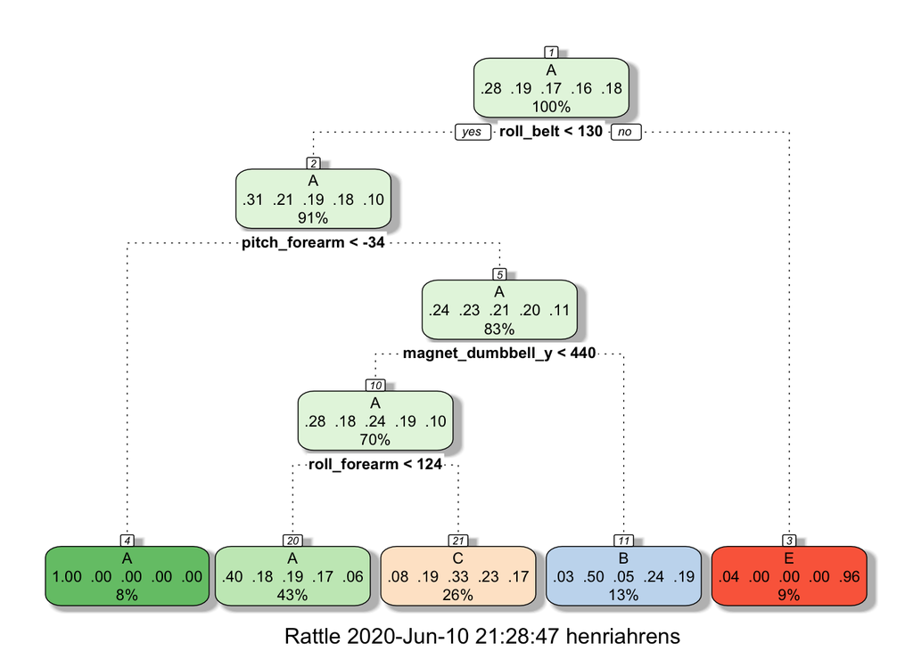

```r
fancyRpartPlot(NikModRpart$finalModel)
```